# Multivariate QTL Mapping with wgAim

Author

Julian Taylor & Ari Verbyla

Published

May 28, 2026

## 1 Overview

This vignette demonstrates the multivariate extension of the **wgAim** QTL mapping pipeline for a biparental mapping population evaluated across multiple trials. The framework detects QTL that act consistently across trials (**main-effect QTL**) as well as QTL whose effects differ between trials (**G×E interaction QTL**), within a unified forward-selection model.

The pipeline has the same three stages as the univariate analysis:

1. **Pre-analysis** — prepare the `wgCross` object using `primeCross()`.
2. **Analysis** — develop a multi-trial base model and run `qtlAim()` with the `Trait` argument to activate the multivariate engine.
3. **Post-analysis** — interrogate, summarise, and visualise the detected QTL using `summary()`, `plot()`, and `aimTrace()`.

The `Trait` argument is a general grouping factor: it may represent trials, environments, sites, treatments, or measured traits — any factor whose levels define the multivariate response. In this vignette `Trait = "Trial"`.

Throughout we use the `genoMVsim` and `phenoMVsim` datasets bundled with the package: a simulated Doubled Haploid (DH) population of 120 lines genotyped at 600 markers across 6 chromosomes, evaluated in 8 field trials with 2 replicates each. Four QTL were planted: two with consistent effects across all trials (main effect) and two with trial-specific effects (G×E).

**Requires:** ASReml-R V4. The vignette is pre-rendered so no licence is needed to read it. Run the code chunks only if you have ASReml-R installed.

## 2 Mathematical Framework

### 2.1 The multivariate linear mixed model

Let $t = 1, \ldots, T$ index trials and let $\boldsymbol{y}_t$ be the $n \times 1$ vector of phenotypic observations for trial $t$. The stacked response across all trials is $\boldsymbol{y} = (\boldsymbol{y}_1^\top, \ldots, \boldsymbol{y}_T^\top)^\top$. The base linear mixed model is

$$\boldsymbol{y} = \boldsymbol{X}\boldsymbol{\tau}
+ \boldsymbol{Z}_u\boldsymbol{u}
+ \boldsymbol{Z}_g\boldsymbol{g}
+ \boldsymbol{e},$$

where $\boldsymbol{X}$ and $\boldsymbol{Z}_u$ are design matrices for the fixed effects $\boldsymbol{\tau}$ (trial means, replicate effects) and peripheral random effects $\boldsymbol{u}$ respectively, and $\boldsymbol{e} \sim \mathcal{N}(\boldsymbol{0},\, \boldsymbol{\Sigma}_e)$ with $\boldsymbol{\Sigma}_e$ a block-diagonal residual structure allowing trial-specific error variances. The genetic line effects $\boldsymbol{g}$ are modelled jointly across trials as

$$\boldsymbol{g} \sim \mathcal{N}\!\left(\boldsymbol{0},\,
\boldsymbol{G}_a \otimes \boldsymbol{I}_n\right),$$

where $\boldsymbol{G}_a$ is the $T \times T$ genetic (co)variance matrix capturing the magnitude of genetic variation in each trial and the genetic correlations between trials.

### 2.2 Factor analytic structure for $\boldsymbol{G}_a$

With many trials, $\boldsymbol{G}_a$ has $T(T+1)/2$ free parameters — too many to estimate reliably unless the number of lines is large. A parsimonious and biologically interpretable approximation is the **factor analytic** (FA) model of order $k$:

$$\boldsymbol{G}_a = \boldsymbol{\Lambda}\boldsymbol{\Lambda}^\top
+ \boldsymbol{\Psi},$$

where $\boldsymbol{\Lambda}$ is the $T \times k$ matrix of factor **loadings** and $\boldsymbol{\Psi} = \text{diag}(\psi_1, \ldots, \psi_T)$ is a diagonal matrix of trial-specific **specific variances**. The loadings capture the dominant axes of genotype-by-trial interaction, while the specific variances absorb any residual trial-specific genetic variation not explained by the common factors. An FA($k$) model has $Tk + T = T(k+1)$ parameters, which is much smaller than the full $T(T+1)/2$ when $k \ll T$.

### 2.3 Introducing additive genetic effects

As in the univariate case, the genetic term $\boldsymbol{g}$ is decomposed into an **additive composite term** $\boldsymbol{a}$ — representing the cumulative effect of all markers across the genome — and a **residual polygenic term** $\boldsymbol{p}$ that absorbs genetic signal not captured by any detected QTL:

$$\boldsymbol{y} = \boldsymbol{X}\boldsymbol{\tau}
+ \boldsymbol{Z}_u\boldsymbol{u}
+ \boldsymbol{Z}_g\boldsymbol{a}
+ \boldsymbol{Z}_g\boldsymbol{p}
+ \boldsymbol{e}.$$

The composite additive term uses one of two equivalent computational paths depending on the ratio of marker intervals $p$ to lines $n$:

- **vm path** ($p > n$): The aggregate marker signal is absorbed into a genomic relationship matrix $\boldsymbol{K} = \tfrac{1}{p}\boldsymbol{M}\boldsymbol{M}^{\top}$, and $\boldsymbol{a} \sim \mathcal{N}(\boldsymbol{0},\, \boldsymbol{G}_a \otimes \boldsymbol{K})$. This is the multivariate extension of the standard GBLUP formulation, efficient when there are more intervals than lines.
- **mbf path** ($n \geq p$): Each marker effect is treated as an independent random regression coefficient, $\boldsymbol{a} = (\boldsymbol{I}_T \otimes \boldsymbol{M})\boldsymbol{q}$ with $\boldsymbol{q} \sim \mathcal{N}(\boldsymbol{0},\, \boldsymbol{G}_a \otimes \sigma^2_q\,\boldsymbol{I}_p)$. This path is preferred when lines outnumber intervals.

Both paths yield identical QTL selection results. The engine selects the appropriate path automatically; the `force = TRUE` argument overrides to the mbf path. In this vignette, with 594 intervals and 120 lines ($p > n$), the vm path is used throughout, and $\boldsymbol{G}_a$ carries the same factor analytic structure as the base model.

### 2.4 Forward selection and the likelihood ratio test

Forward selection proceeds identically to the univariate case. At each iteration a likelihood ratio test (LRT) is used to determine whether any interval or marker carries significant additive signal. For $T$ trials, however, each candidate is tested as a $T$-vector of fixed effects — one per trial — so the test statistic follows a **chi-squared mixture** distribution rather than a standard $\chi^2_1$:

$$\Lambda = -2\!\left(\ell_{\text{reduced}} - \ell_{\text{full}}\right)
\;\stackrel{\text{approx.}}{\sim}\;
\sum_{j=0}^{T} w_j \,\chi^2_j,$$

where the mixing weights $w_j = \binom{T}{j} \tfrac{1}{2^T}$ arise from the boundary constraints on variance components, and $\ell$ is the restricted log-likelihood. The mixture critical value at family-wise significance level `TypeI` is obtained numerically via `qchisq.mixture()`.

### 2.5 Genome-wide outlier statistic

Because the BLUP of interval $k$’s additive effect is now a $T$-vector $\tilde{\boldsymbol{q}}_k$, the outlier statistic is a **quadratic form** in $\boldsymbol{G}_a^{-1}$:

$$o_k = \frac{\tilde{\boldsymbol{q}}_k^\top\,
\boldsymbol{G}_a^{-1}\,\tilde{\boldsymbol{q}}_k}{\tilde{v}_k},$$

where the normalising scalar $\tilde{v}_k = \text{tr}\!\left(\boldsymbol{G}_a^{-1}\, \boldsymbol{T}_k\,\tilde{\boldsymbol{V}}_{\boldsymbol{a}}\, \boldsymbol{T}_k^\top\right)$, $\boldsymbol{T}_k = \boldsymbol{I}_T \otimes \boldsymbol{t}_k^\top$ is the extraction matrix for interval $k$, and $\tilde{\boldsymbol{V}}_{\boldsymbol{a}}$ is the posterior variance matrix of the composite random term.

### 2.6 Post-selection: main-effect vs G×E QTL

After all QTL have been selected, a Wald zero-equality test is applied to the $T$-vector of fixed effects for each detected QTL. QTL whose effects are consistent across trials (main effects) are retained with a single fixed coefficient; those with significant trial-specific variation are retained as a full $T$-vector of trial-specific effects (G×E interaction QTL). The final model is

$$\boldsymbol{y} = \boldsymbol{X}\boldsymbol{\tau}
+ \boldsymbol{Z}_g\!\sum_{j \in \mathcal{M}} \hat{\beta}_j\,\boldsymbol{x}_j
+ \boldsymbol{Z}_g\!\sum_{k \in \mathcal{I}}
\hat{\boldsymbol{\gamma}}_k^\top\,\boldsymbol{x}_k
+ \boldsymbol{Z}_u\boldsymbol{u}
+ \boldsymbol{Z}_g\boldsymbol{a}_{-s}
+ \boldsymbol{Z}_g\boldsymbol{p}
+ \boldsymbol{e},$$

where $\boldsymbol{a}_{-s} = \boldsymbol{M}_{-s}\boldsymbol{q}_{-s}$ where the $\boldsymbol{M}_{-s}$ denotes $\boldsymbol{M}$ with an omission of markers/intervals in the windows of the QTL selected; $\mathcal{M}$ denotes main-effect QTL with scalar effects $\hat{\beta}_j$ and $\mathcal{I}$ denotes G×E QTL with trial-specific effect vectors $\hat{\boldsymbol{\gamma}}_k$.

## 3 Data Preparation — `primeCross()`

```r
data(genoMVsim,  package = "wgAim")
data(phenoMVsim, package = "wgAim")
```

`primeCross()` converts the `cross` object into a `wgCross` object with interval genotype scores ready for `qtlAim()`:

```r
genObj <- primeCross(genoMVsim, type = "interval", id = "id")
```

```r
n_chr <- length(genObj$geno)
n_int <- sum(sapply(genObj$geno, function(ch) ncol(ch$interval.data)))
n_mk  <- sum(sapply(genObj$geno, function(ch) ncol(ch$data)))
cat(sprintf("Chromosomes : %d\n", n_chr))
```

```
Chromosomes : 6
```

```r
cat(sprintf("Markers     : %d\n", n_mk))
```

```
Markers     : 600
```

```r
cat(sprintf("Intervals   : %d\n", n_int))
```

```
Intervals   : 594
```

```r
cat(sprintf("Lines       : %d\n", nrow(genObj$pheno)))
```

```
Lines       : 120
```

With 594 intervals and 120 lines, the ratio $p/n > 1$ and `qtlAim()` will automatically use the `vm` (genomic relationship matrix) engine path.

## 4 Base Model Development

The starting point for a multivariate analysis is a converged multi-trial base model that captures the experimental design structure and the genetic (co)variance across trials. We build this incrementally, comparing three variance structures for the genetic term.

```r
phenoMVsim$id    <- factor(phenoMVsim$id)
phenoMVsim$Trial <- factor(phenoMVsim$Trial,
                           levels = paste0("Trial", 1:8))
phenoMVsim$Rep   <- factor(phenoMVsim$Rep)
```

### 4.1 Step 1 — Diagonal structure

The simplest multi-trial model assumes genetic effects in each trial are **independent**: a diagonal $\boldsymbol{G}_a = \text{diag}(\sigma^2_{g,1}, \ldots, \sigma^2_{g,T})$ with no between-trial genetic correlations. This is the natural starting point.

```r
base_diag <- asreml(
  fixed     = yield ~ Trial + Trial:Rep,
  random    = ~ diag(Trial):id,
  residual  = ~ dsum(~units | Trial),
  data      = phenoMVsim,
  na.action = na.method(x = "include"),
  maxit     = 80
)
base_diag <- update(base_diag)
```

### 4.2 Step 2 — Factor analytic order 1

A single-factor model FA(1) introduces one set of loadings and captures the dominant axis of genotype-by-trial interaction:

```r
base_fa1 <- asreml(
  fixed     = yield ~ Trial + Trial:Rep,
  random    = ~ fa(Trial, 1):id,
  residual  = ~ dsum(~units | Trial),
  data      = phenoMVsim,
  na.action = na.method(x = "include"),
  maxit     = 80
)
base_fa1 <- update(base_fa1)
```

### 4.3 Step 3 — Factor analytic order 2

A two-factor model FA(2) captures two axes of interaction and provides a richer description of the genetic covariance structure. This is the model we will carry into `qtlAim()`:

```r
base_fa2 <- asreml(
  fixed     = yield ~ Trial + Trial:Rep,
  random    = ~ fa(Trial, 2):id,
  residual  = ~ dsum(~units | Trial),
  data      = phenoMVsim,
  na.action = na.method(x = "include"),
  maxit     = 80
)
base_fa2 <- update(base_fa2)
```

### 4.4 Model comparison

```r
aic <- function(mod, k) -2 * mod$loglik + 2 * k
# Parameters: diag = 8 var; fa1 = 8 psi + 8 load = 16; fa2 = 8 psi + 16 load = 24
mod_comp <- data.frame(
  Model      = c("diag(Trial)", "fa(Trial, 1)", "fa(Trial, 2)"),
  Parameters = c(8L, 16L, 24L),
  LogLik     = round(c(base_diag$loglik, base_fa1$loglik, base_fa2$loglik), 2),
  AIC        = round(c(aic(base_diag, 8), aic(base_fa1, 16), aic(base_fa2, 24)), 2)
)
print(mod_comp, row.names = FALSE)
```

```
        Model Parameters  LogLik     AIC
  diag(Trial)          8 -932.49 1880.99
 fa(Trial, 1)         16 -889.96 1811.92
 fa(Trial, 2)         24 -884.31 1816.63
```

## 5 QTL Mapping — `qtlAim()`

### 5.1 Running `qtlAim()`

The `Trait` argument activates the multivariate engine, treating `"Trial"` as the grouping factor. Leaving `str = NULL` (the default) instructs `qtlAim()` to mirror the variance structure of the base model — here FA(2) — for the composite genome-wide random term, giving consistent modelling of the genetic covariance at every iteration without needing to respecify the order:

```r
qtl_mv <- qtlAim(
  baseModel        = base_fa2,
  genObj           = genObj,
  merge.by         = "id",
  Trait            = "Trial",
  exclusion.window = 20,
  TypeI            = 0.01,
  trace            = FALSE,
  na.action        = na.method(x = "include"),
  maxit            = 80
)
```

```r
cat("Class        :", paste(class(qtl_mv), collapse = ", "), "\n")
```

```
Class        : qtlAim, asreml
```

```r
cat("Engine       :", qtl_mv$QTL$path, "\n")
```

```
Engine       :
```

```r
cat("QTL detected :", length(qtl_mv$QTL$qtl), "\n")
```

```
QTL detected : 4
```

```r
cat("QTL keys     :", paste(qtl_mv$QTL$qtl, collapse = ", "), "\n")
```

```
QTL keys     : Chr.Chr3.40, Chr.Chr1.22, Chr.Chr2.56, Chr.Chr5.66
```

## 6 Results

### 6.1 `summary()` — final QTL table

```r
summ_mv <- summary(qtl_mv, genObj = genObj)
print(summ_mv)
```

```
    Trait Chromosome Left Marker dist(cM) Infer. Marker dist(cM) Right Marker
1    MAIN       Chr1       D1M22       21   Chr1.midm22     21.5        D1M23
2  Trial1       Chr2       D2M56       55   Chr2.midm56     55.5        D2M57
3  Trial2       Chr2       D2M56       55   Chr2.midm56     55.5        D2M57
4  Trial3       Chr2       D2M56       55   Chr2.midm56     55.5        D2M57
5  Trial4       Chr2       D2M56       55   Chr2.midm56     55.5        D2M57
6  Trial5       Chr2       D2M56       55   Chr2.midm56     55.5        D2M57
7  Trial6       Chr2       D2M56       55   Chr2.midm56     55.5        D2M57
8  Trial7       Chr2       D2M56       55   Chr2.midm56     55.5        D2M57
9  Trial8       Chr2       D2M56       55   Chr2.midm56     55.5        D2M57
10   MAIN       Chr3       D3M40       39   Chr3.midm40     39.5        D3M41
11 Trial1       Chr5       D5M66       65   Chr5.midm66     65.5        D5M67
12 Trial2       Chr5       D5M66       65   Chr5.midm66     65.5        D5M67
13 Trial3       Chr5       D5M66       65   Chr5.midm66     65.5        D5M67
14 Trial4       Chr5       D5M66       65   Chr5.midm66     65.5        D5M67
```

[output cut: 23 more lines]

## 7 Visualisation — `plot()`

### 7.1 Genome-wide outlier statistics — `type = "outlier"`

The outlier statistic $o_k = \tilde{\boldsymbol{q}}_k^\top \boldsymbol{G}_a^{-1}\tilde{\boldsymbol{q}}_k / \tilde{v}_k$ is plotted across the genome for each forward-selection iteration. Because the statistic is a quadratic form it is strictly non-negative, and its profile reveals which chromosomal regions carry the strongest multi-trial signal at each step:

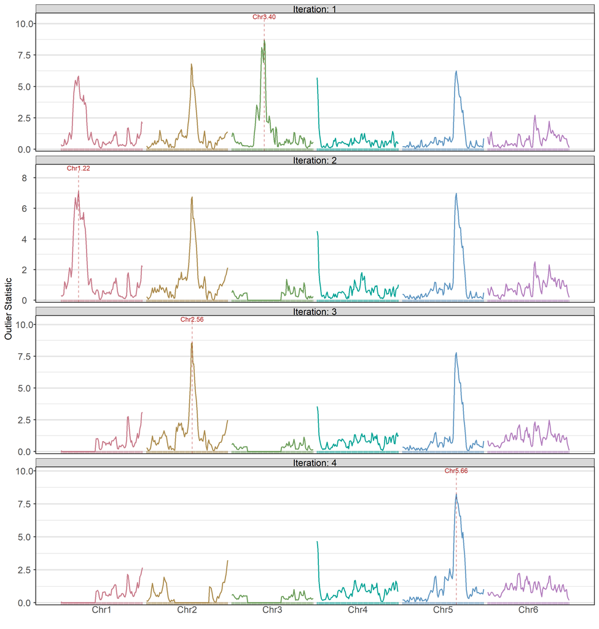

```r
plot(qtl_mv, genObj = genObj, type = "outlier", sig.col = "firebrick")
```

### 7.2 Scaled genome-wide BLUPs — `type = "blups"`

For a multivariate analysis, the BLUPs plot shows one line per trial, coloured by trial. This display is particularly informative: intervals where all trial lines move together indicate main-effect signal, while intervals where trial lines diverge or cross indicate G×E signal:

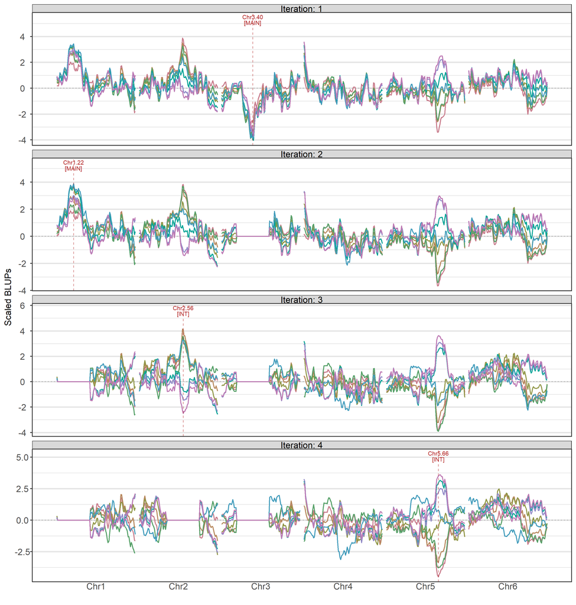

Scaled composite BLUPs across the genome at each iteration, coloured by trial. Convergent lines = consistent main-effect signal; divergent or crossing lines = G×E signal.

```r
plot(qtl_mv, genObj = genObj, type = "blups", sig.col = "firebrick")
```

### 7.3 Allele effects — `type = "effects"`

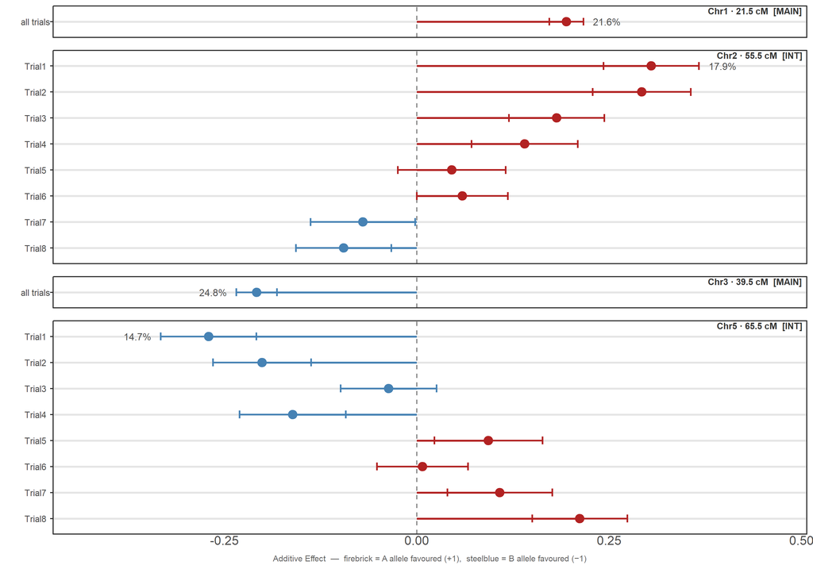

```r
plot(qtl_mv, genObj = genObj, type = "effects")
```

### 7.4 Allele contrast — `type = "contrast"`

The contrast plot shows the total genetic value per line against its allele class at each detected QTL, separately for each trial. Main-effect QTL show the same direction of separation across all trial panels; G×E QTL show the separation varying or reversing between trial panels:

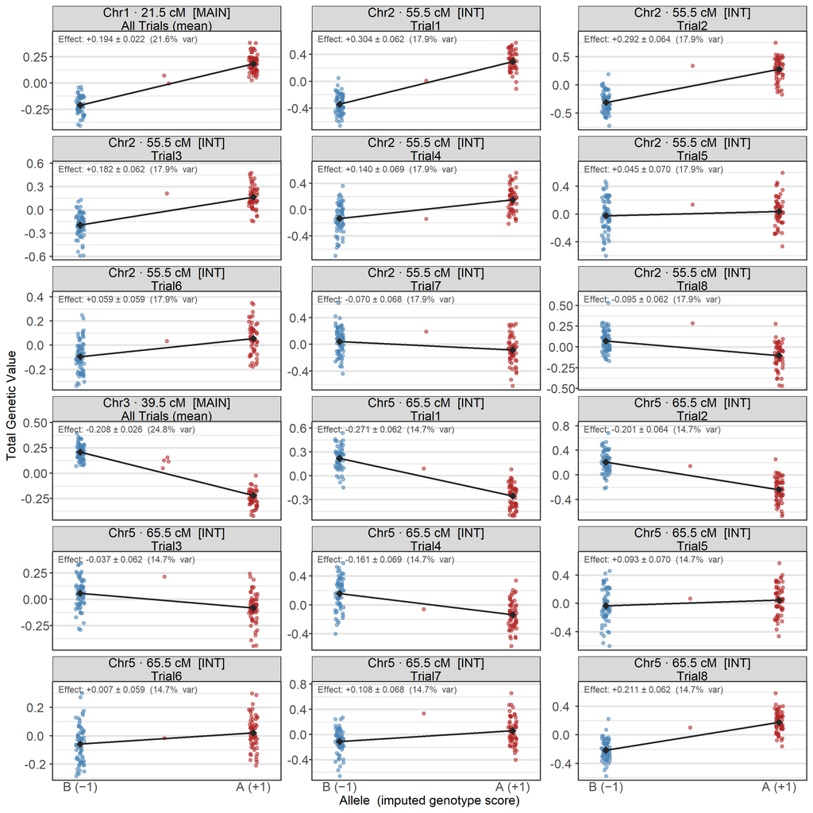

```r
plot(qtl_mv, genObj = genObj, type = "contrast", data = phenoData, ncol = 3)
```

## 8 Iteration Diagnostics — `aimTrace()`

### 8.1 LRT trace — `plot = "lrt"`

The mixture chi-squared threshold (shown as a dashed line) reflects the $T$-dimensional nature of the test — it lies above the univariate $\chi^2_1$ threshold because the test jointly evaluates effects across all $T$ trials:

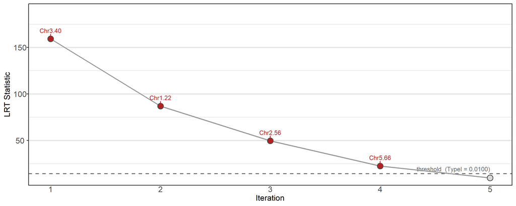

LRT statistic at each forward-selection iteration. The dashed line is the chi-squared mixture threshold at TypeI = 0.01 for T = 8 trials.

```r
aimTrace(qtl_mv, plot = "lrt", print.out = FALSE)
```

### 8.2 Effect stability — `plot = "stability"`

The stability plot traces the per-trial allele effect ± 1 SE for each detected QTL across iterations. Stable main-effect QTL show all trial lines tracking closely together; G×E QTL show trial lines that are separated or diverge as further QTL enter the model:

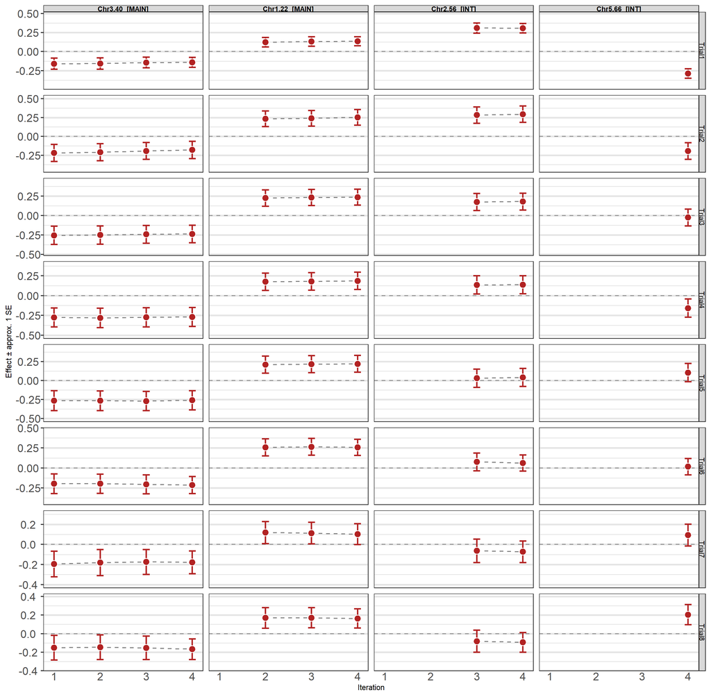

Per-trial allele effect estimates ± approx. 1 SE (points with error bars) across iterations. Rows = trials; columns = detected QTL with [MAIN] or [INT] suffix. Stable QTL show consistent effects across iterations; G×E QTL show trial-dependent variation.

```r
aimTrace(qtl_mv, plot = "stability", print.out = FALSE)
```

## 9 Summary

The complete multivariate pipeline illustrated in this vignette is:

```r
# 1. Prepare genotype data
genObj <- primeCross(genoMVsim, type = "interval", id = "id")

# 2. Build up the base model
base_diag <- asreml(yield ~ Trial + Trial:Rep,
                    random = ~ diag(Trial):id,
                    residual = ~ dsum(~units | Trial), data = phenoMVsim, ...)
base_fa1  <- asreml(yield ~ Trial + Trial:Rep,
                    random = ~ fa(Trial, 1):id,
                    residual = ~ dsum(~units | Trial), data = phenoMVsim, ...)
base_fa2  <- asreml(yield ~ Trial + Trial:Rep,
                    random = ~ fa(Trial, 2):id,
                    residual = ~ dsum(~units | Trial), data = phenoMVsim, ...)

# 3. Multivariate QTL mapping
qtl_mv <- qtlAim(base_fa2, genObj = genObj, merge.by = "id",
                 Trait = "Trial", TypeI = 0.01,
                 na.action = na.method(x = "include"), maxit = 80, ...)

# 4. Results
summary(qtl_mv, genObj = genObj)          # final QTL table (MAIN/INT)
plot(qtl_mv, genObj = genObj, type = "outlier")  # quadratic-form outlier stats
plot(qtl_mv, genObj = genObj, type = "blups")    # multi-trial BLUPs
plot(qtl_mv, genObj = genObj, type = "effects")  # per-trial effect lollipop
plot(qtl_mv, genObj = genObj, type = "contrast", data = phenoData, ncol = 3)
aimTrace(qtl_mv, plot = "lrt",       print.out = FALSE)
aimTrace(qtl_mv, plot = "stability", print.out = FALSE)
```

## 10 References

Verbyla, A.P., Cullis, B.R. & Thompson, R. (2007). The analysis of QTL by simultaneous use of the full linkage map. *Theoretical and Applied Genetics*, **116**, 95–111. https://doi.org/10.1007/s00122-007-0676-4

Verbyla, A.P., Taylor, J.D. & Verbyla, K.L. (2012). RWGAIM: An efficient high-dimensional random whole genome average (QTL) interval mapping approach. *Genetics Research*, **94**, 291–306. https://doi.org/10.1017/S0016672312000493

Taylor, J. & Verbyla, A.P. (2011). R Package wgaim: QTL Analysis in Bi-Parental Populations Using Linear Mixed Models. *Journal of Statistical Software*, **40**(7), 1–18. https://doi.org/10.18637/jss.v040.i07

Smith, A.B., Cullis, B.R. & Thompson, R. (2001). Analyzing variety by environment data using multiplicative mixed models and adjustments for spatial field trend. *Biometrics*, **57**(4), 1138–1147. https://doi.org/10.1111/j.0006-341X.2001.01138.x

Haldane, J.B.S. (1919). The combination of linkage values and the calculation of distances between the loci of linked factors. *Journal of Genetics*, **8**(29), 299–309.